# Guinea pig’s tooth growth analysis

Kirill Panarin

## Overview

The response is the length of odontoblasts (teeth) in each of 10 guinea pigs at each of three dose levels of Vitamin C (0.5, 1, and 2 mg) with each of two delivery methods (orange juice or ascorbic acid).

ToothGrowth data set contains 3 variables:

- **len**: tooth length, numeric
- **supp**: supplement type (VC or OJ), factor
- **dose**: dose in milligrams, numeric

## Exploratory analysis

Let’s load ToothGrowth data set and display structure of it:

```r
data(ToothGrowth)
str(ToothGrowth)
```

```
## 'data.frame':    60 obs. of  3 variables:
##  $ len : num  4.2 11.5 7.3 5.8 6.4 10 11.2 11.2 5.2 7 ...
##  $ supp: Factor w/ 2 levels "OJ","VC": 2 2 2 2 2 2 2 2 2 2 ...
##  $ dose: num  0.5 0.5 0.5 0.5 0.5 0.5 0.5 0.5 0.5 0.5 ...
```

```r
summary(ToothGrowth)
```

```
##       len        supp         dose
##  Min.   : 4.20   OJ:30   Min.   :0.500
##  1st Qu.:13.07   VC:30   1st Qu.:0.500
##  Median :19.25           Median :1.000
##  Mean   :18.81           Mean   :1.167
##  3rd Qu.:25.27           3rd Qu.:2.000
##  Max.   :33.90           Max.   :2.000
```

```r
head(ToothGrowth)
```

```
##    len supp dose
## 1  4.2   VC  0.5
## 2 11.5   VC  0.5
## 3  7.3   VC  0.5
## 4  5.8   VC  0.5
## 5  6.4   VC  0.5
## 6 10.0   VC  0.5
```

So we have a data set with 60 observations of 3 variables. It will be better to convert `dose` variable from numeric to factor:

```r
ToothGrowth$dose <-as.factor(ToothGrowth$dose)
```

Let’s plot how `len` is distributed for different `supp` and `dose` in order to highlight some basic features of the data:

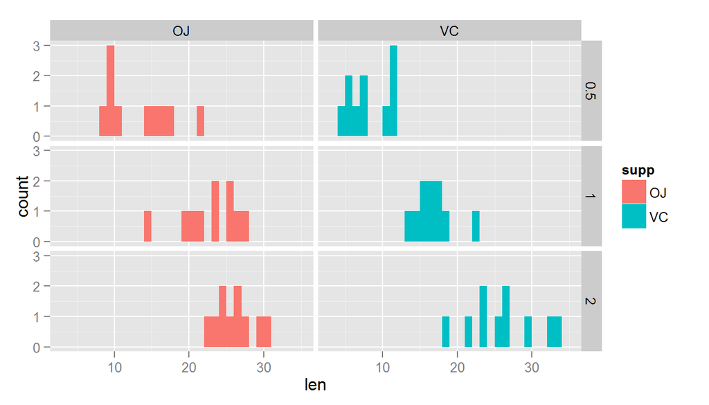

Base on the figure above we can assume that as dose increases the chances to get higher tooth length become higher.

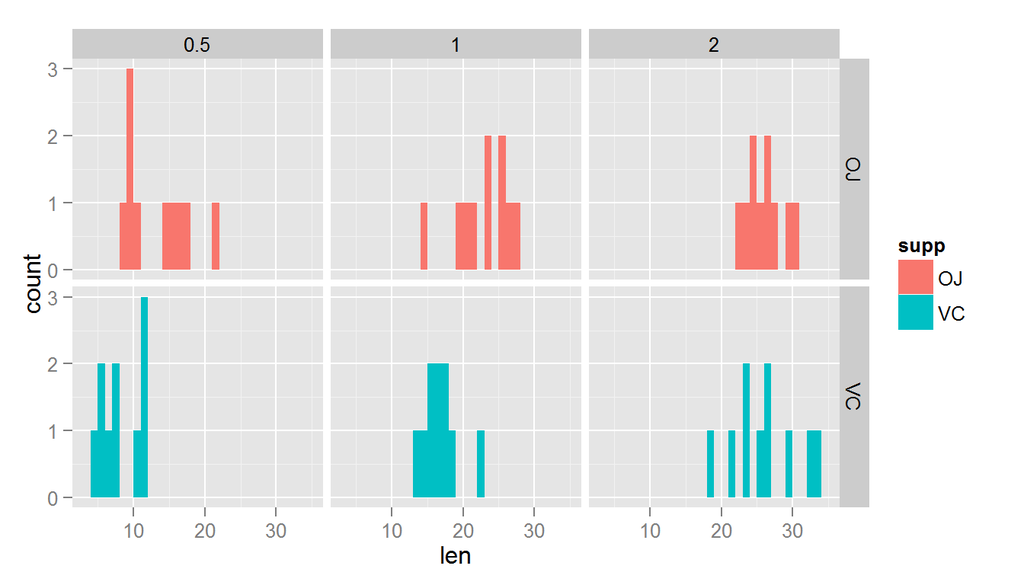

Based on the figure above, I can’t assume that supplement type somehow affects tooth growth rate.

## Tooth growth by supp and dose comparison

### Comparison by supp

First, let’s apply t-statistics for length by supplement type for each dose:

```r
stat_by_supp <- sapply(unique(ToothGrowth$dose), function(d) {
    stat <- t.test(len ~ supp, paired = F, var.equal = F, data = ToothGrowth[ToothGrowth$dose == d,])
    stat$dose <- as.character(d)
    stat$conf.int_min <- stat$conf.int[1]
    stat$conf.int_max <- stat$conf.int[2]
    stat
})
t(stat_by_supp)[, c(10, 1:3, 11, 12)]
```

```
##      dose  statistic  parameter p.value     conf.int_min conf.int_max
## [1,] "0.5" 3.169733   14.96875  0.006358607 1.719057     8.780943
## [2,] "1"   4.03277    15.35767  0.001038376 2.802148     9.057852
## [3,] "2"   -0.0461361 14.03982  0.9638516   -3.79807     3.63807
```

For doses 0.5 and 1 we have high t-statistics and low p-value (< 5%), so we have to reject null hypothesis and assume that supplement type OJ is more effective than VC i.e. **orange juice is more effective than ascorbic acid for small doses**. In contrast, for dose 2 t-statistics is small, p-value is high (>>5%) and 0 is in the confidence interval, so we can assume that **for big doses supplement type doesn’t play significant role in tooth growth rate**.

### Comparison by dose

In this case we have more analysis permutation than in the case with comparison by supp. There are three combinations of doses. Let’s run t-statistics for all of them:

```r
dose_combn <- combn(as.character(unique(ToothGrowth$dose)), 2)
stat_by_dose <- mapply(function(f, s) {
    dose_pair <- c(f, s)
    stat <- t.test(len ~ dose, paired = F, var.equal = F, data = ToothGrowth[ToothGrowth$dose %in% dose_pair,])
    stat$conf.int_min <- stat$conf.int[1]
    stat$conf.int_max <- stat$conf.int[2]
    stat$dose.first <- dose_pair[1]
    stat$dose.second <- dose_pair[2]
    stat
}, dose_combn[1, ], dose_combn[2, ])
colnames(stat_by_dose) <- c()
t(stat_by_dose)[, c(12, 13, 1:3, 10, 11)]
```

```
##      dose.first dose.second statistic parameter p.value      conf.int_min
## [1,] "0.5"      "1"         -6.476648 37.98641  1.268301e-07 -11.98378
## [2,] "0.5"      "2"         -11.79905 36.88259  4.397525e-14 -18.15617
## [3,] "1"        "2"         -4.900484 37.10109  1.90643e-05  -8.996481
##      conf.int_max
## [1,] -6.276219
## [2,] -12.83383
## [3,] -3.733519
```

As we can see in all case t-statistic is big and p-value is small, and 0 doesn’t fall into confidence interval, so we can reject null hypothesis and assume that **as dose increases tooth growth rate increases too**.